# Group 6 EDA

### Correlation Matrix of Modified Dataset

#### Predictability of Future Orders:

The strong correlation between orders in consecutive years suggests that past behavior is a reliable predictor of future orders.

#### Channel Independence:

Weak correlations between channels like CALL CENTER and others suggest that customers typically prefer specific channels rather than mixing them.

```r
# Select only numeric columns
numeric_data <- complete_data %>%
  select(where(is.numeric))

# Calculate correlation matrix
cor_matrix <- cor(numeric_data, use = "complete.obs")
print(cor_matrix)
```

```
##                  CUSTOMER_NUMBER total_order_2023 total_order_2024
## CUSTOMER_NUMBER      1.000000000       0.06380331       0.05660393
## total_order_2023     0.063803311       1.00000000       0.96151440
## total_order_2024     0.056603933       0.96151440       1.00000000
## percent_change               NaN              NaN              NaN
## SALES REP            0.038555926       0.43924086       0.44062975
## CALL CENTER          0.028367619       0.63229594       0.61025999
## null                 0.008116144       0.03017881       0.03208627
## MYCOKE LEGACY        0.038168447       0.53843757       0.56572063
## MYCOKE360            0.037440523       0.53490378       0.58789634
## OTHER                0.020764023       0.51876731       0.45906355
## EDI                  0.027712794       0.31064944       0.35244716
##                  percent_change  SALES REP   CALL CENTER          null
## CUSTOMER_NUMBER             NaN 0.03855593  0.0283676193  0.0081161441
## total_order_2023            NaN 0.43924086  0.6322959393  0.0301788114
## total_order_2024            NaN 0.44062975  0.6102599916  0.0320862715
## percent_change                1        NaN           NaN           NaN
## SALES REP                   NaN 1.00000000  0.2614697695  0.0110631724
## CALL CENTER                 NaN 0.26146977  1.0000000000 -0.0003072461
## null                        NaN 0.01106317 -0.0003072461  1.0000000000
## MYCOKE LEGACY               NaN 0.02973205  0.0009304160 -0.0049483711
## MYCOKE360                   NaN 0.03006678  0.0048229303 -0.0032748816
## OTHER                       NaN 0.02100556  0.1284127221  0.0049264022
## EDI                         NaN 0.00291460  0.0002477156  0.0026238889
##                  MYCOKE LEGACY    MYCOKE360       OTHER           EDI
## CUSTOMER_NUMBER    0.038168447  0.037440523 0.020764023  0.0277127935
## total_order_2023   0.538437566  0.534903782 0.518767306  0.3106494389
## total_order_2024   0.565720631  0.587896342 0.459063551  0.3524471604
## percent_change             NaN          NaN         NaN           NaN
## SALES REP          0.029732045  0.030066780 0.021005560  0.0029146001
## CALL CENTER        0.000930416  0.004822930 0.128412722  0.0002477156
## null              -0.004948371 -0.003274882 0.004926402  0.0026238889
## MYCOKE LEGACY      1.000000000  0.942156968 0.145835428 -0.0058358289
## MYCOKE360          0.942156968  1.000000000 0.212532712 -0.0043481705
## OTHER              0.145835428  0.212532712 1.000000000  0.0551583590
## EDI               -0.005835829 -0.004348170 0.055158359  1.0000000000
```

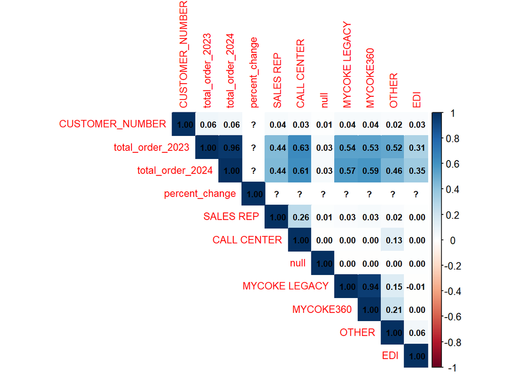

```r
# Visualize using corrplot
corrplot(cor_matrix, method = "color", type = "upper", tl.cex = 0.8, number.cex = 0.7, addCoef.col = "black")
```

# Results

The initial target variable for this analysis was a threshold of 400 gallons per year. Additionally, a second target variable was explored, capturing the percent change in order volume from 2023 to 2024.

Analysis of customer orders revealed a notable decline in orders from 2023 to 2024. The number of customers who increased their order volume was approximately 1,000 fewer than those who reduced their orders, with only 146 customers maintaining the same order volume as the previous year. This substantial drop in order activity calls for further investigation to understand the factors influencing the few customers who did increase their orders, as well as the reasons behind the overall decline.

In 2024, 2,119 customers received their first delivery, suggesting a positive rate of new customer acquisition. However, the data also suggests a trend where companies with longer duration since their first order experience slower growth, as the average growth percentage decreases over time. This indicates that older companies may be facing challenges in sustaining growth and indicates a desire for further investigation to identify key differences between high and low-growth companies.

# Group Member Contribution

Andy Spendlove:

- Built preliminary solo EDA for review with group
- Wrote code in Explore Data section
- Plotted Barplots for Categorical Variables
- Plotted Ordered_Volume by Categorical Variables
- Created correlation matrix between numeric transaction features
- Assisted in final compilation meetings

Dan Powell:

- Built preliminary solo EDA for review with group
- Wrote code for Cleaning and Joining
- Assisted in final compilation meetings
- Led the use of Google Colab
- Export and final formatting review

Jessica Kersey:

- Built preliminary solo EDA for review with group
- Wrote Introduction section
- Notebook organization (TOC, headers, grouping/reordering sections)
- Provided code for engineering 400 gallon avg per year target variable
- Assisted in final compilation

Melissa Messervy:

- Built preliminary solo EDA for review with group
- Wrote Describe Data section
- Wrote Results section
- Assisted in final compilation meetings
- Final review andedits of written sections

Tommaso Pascucci:

- Built preliminary solo EDA for review with group
- Wrote code in Explore Data section
- Engineering additional possible target variable of percent change (in gallons ordered from 2023 to 2024)
- Explored customer features
- Created correlation plots